# Eric_Hirsch_624_Homework_6

y <- numeric(100)\ e <- rnorm(100)\ for(i in 2:100)\ y[i] <- e[i] + 0.6*e[i-1]\ sim2 <- tsibble(idx = seq_len(100), y = y, index = idx)\

*9.6d Produce a time plot for the series. How does the plot change?*

The plot becomes denser with decreasing levels of phi.

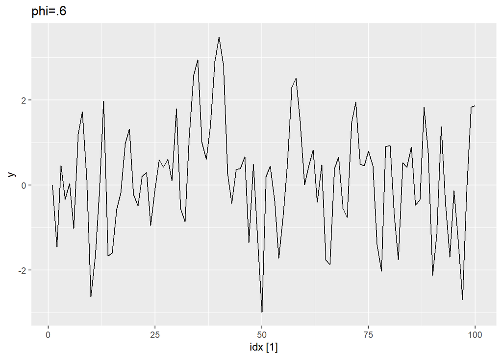

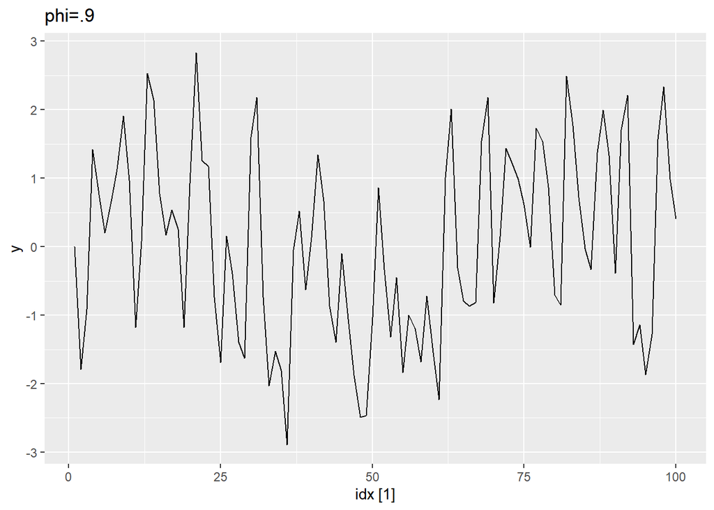

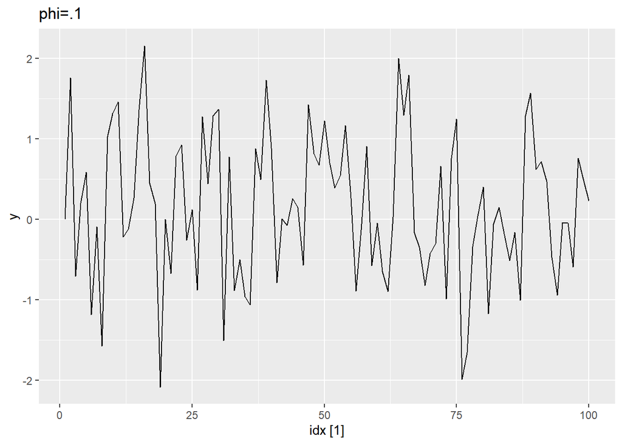

__*9.6e Generate data from an ARMA(1,1) model.__*

y <- numeric(100)\ e <- rnorm(100)\ for(i in 2:100)\ y[i] <- e[i] + .6*e[i-1] + 0.6*y[i-1]\ sim3 <- tsibble(idx = seq_len(100), y = y, index = idx)\

*9.6f Generate data from an AR(2) model.*

y <- numeric(100)\ e <- rnorm(100)\ for(i in 3:100)\ y[i] <- e[i] -.8*y[i-1] + .3*y[i-2]\ sim4 <- tsibble(idx = seq_len(100), y = y, index = idx)\

*9.6g Graph the latter two series and compare them.*

The graphs are very different. The first graph looks more like a typical, cycle-driven time series. The second looks like the poster child for heteroskedasticity. It would suggest a series that is inversely related to the previous period, but positively related to the 2nd one back.

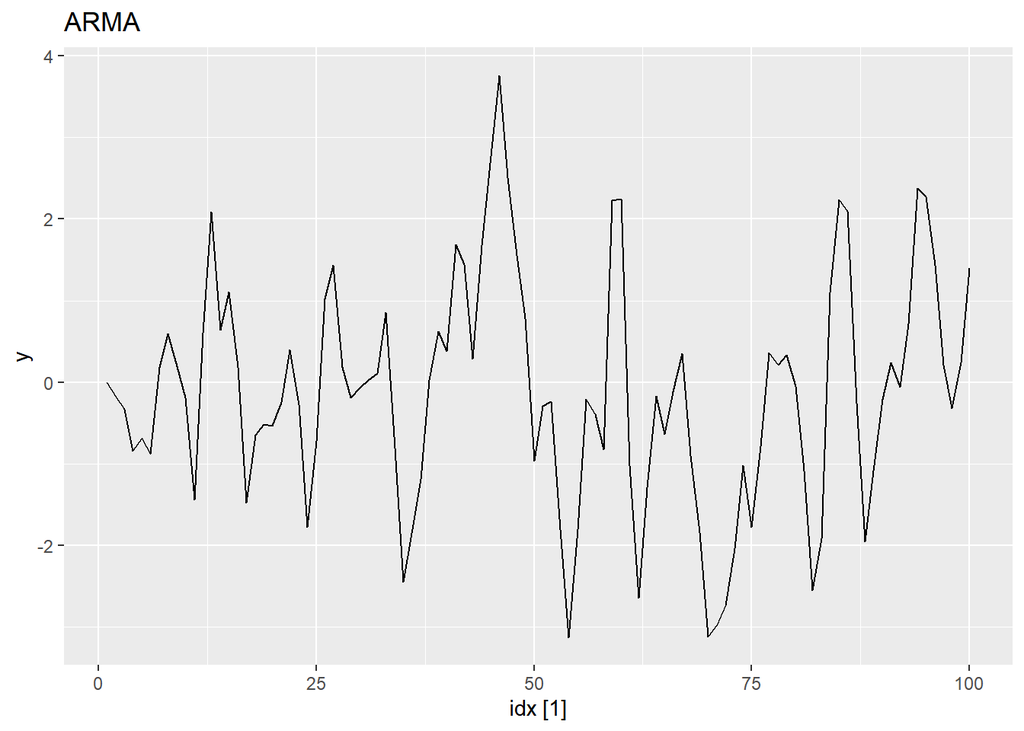

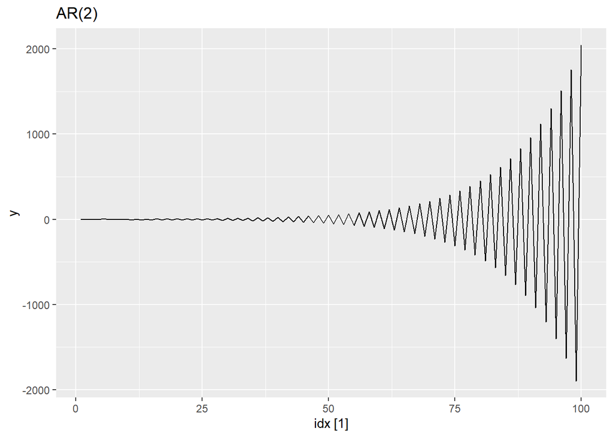

### 9.7

*9.7 Consider aus_airpassengers, the total number of passengers (in millions) from Australian air carriers for the period 1970-2011.*

*9.7a Use ARIMA() to find an appropriate ARIMA model. What model was selected. Check that the residuals look like white noise. Plot forecasts for the next 10 periods.*

ARIMA(0,2,1) was selected. The residuals look like white noise.

```
## Series: Passengers
## Model: ARIMA(0,2,1)
##
## Coefficients:
##           ma1
##       -0.8963
## s.e.   0.0594
##
## sigma^2 estimated as 4.308:  log likelihood=-97.02
## AIC=198.04   AICc=198.32   BIC=201.65
```

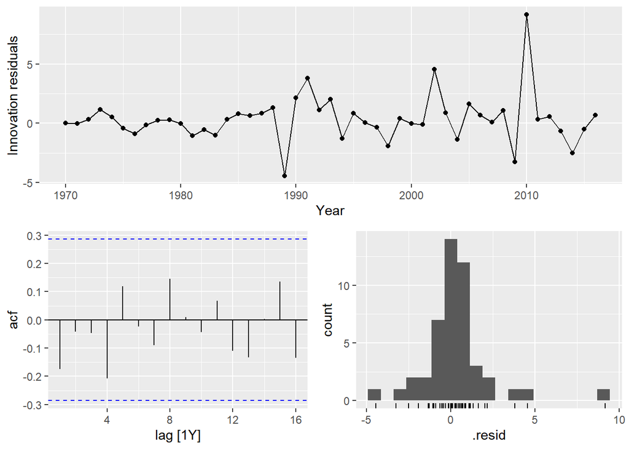

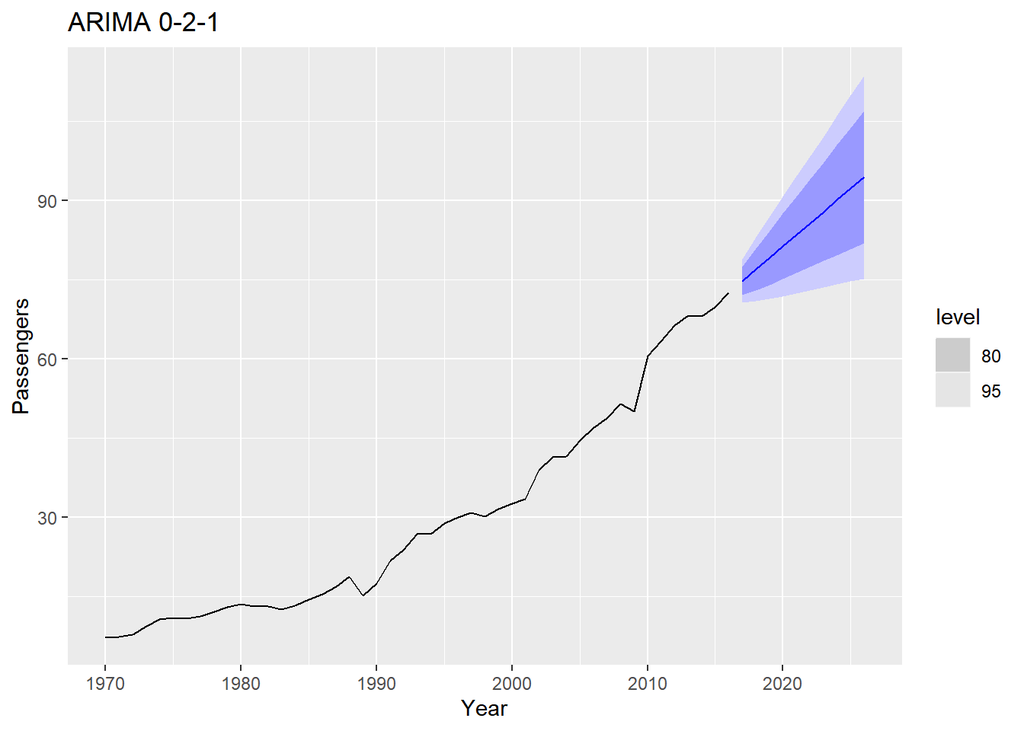

*9.7b Write the model in terms of the backshift operator.*

$$\begin{equation}
\tag{9.2}
\begin{array}{c c c c}
(1-\phi_1B - \cdots - \phi_p B^p) & (1-B)^d y_{t} &= &c
+ (1 + \theta_1 B + \cdots + \theta_q B^q)\varepsilon_t\\
{\uparrow} & {\uparrow} & &{\uparrow}\\
\text{AR($p$)} & \text{$d$ differences} & &
\text{MA($q$)}\\
\end{array}
\end{equation}$$

*9.7c Plot forecasts from an ARIMA(0,1,0) model with drift and compare these to part a.*

Not surprisingly, the second model climbs at a lower rate.

```
## Series: Passengers
## Model: ARIMA(0,1,0) w/ drift
##
## Coefficients:
##       constant
##         1.4191
## s.e.    0.3014
##
## sigma^2 estimated as 4.271:  log likelihood=-98.16
## AIC=200.31   AICc=200.59   BIC=203.97
```

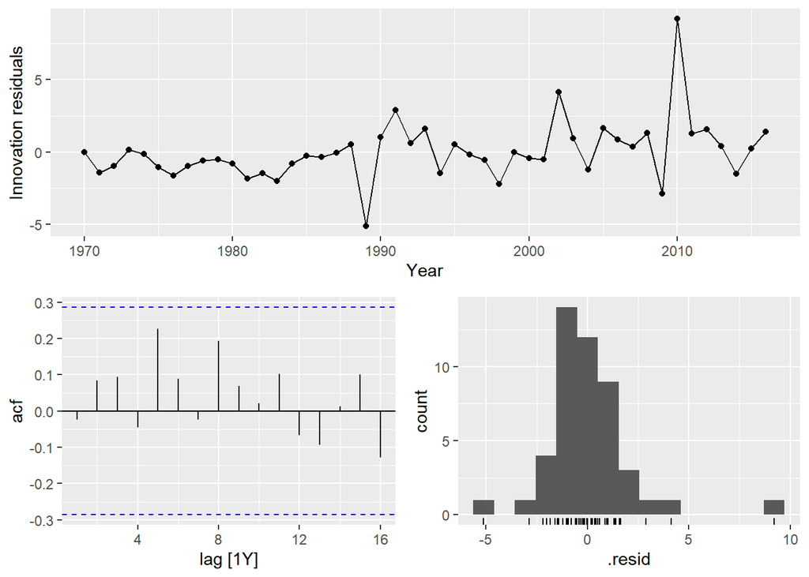

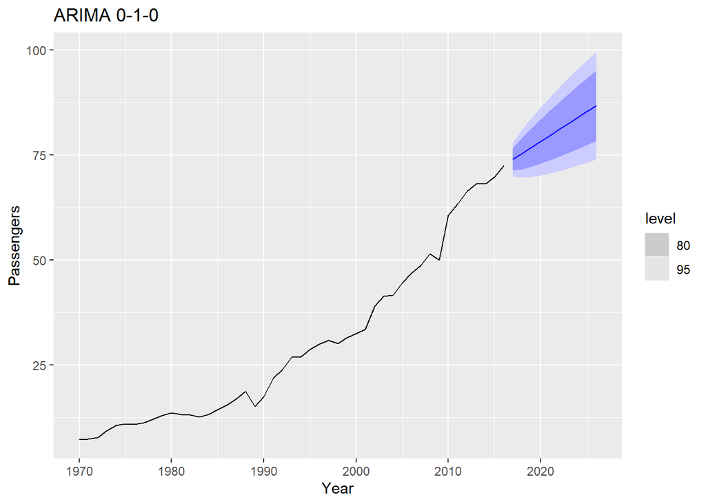

*9.7d Plot forecasts from an ARIMA(2,1,2) model with drift and compare these to parts a and c. Remove the constant and see what happens.*

You can plot ARIMA(1,1,2) or ARIMA(2,1,1) but not ARIMA(2,1,2) - this just gives you null.If you try (1,1,2) and remove the constant, you again get a null model.

*9.7e Plot forecasts from an ARIMA(0,2,1) model with a constant. What happens?*

The ARIMA(0,2,1) model does not generate a constant. If we force one, the model is null.

```
## Series: Passengers
## Model: ARIMA(0,2,1)
##
## Coefficients:
##           ma1
##       -0.8963
## s.e.   0.0594
##
## sigma^2 estimated as 4.308:  log likelihood=-97.02
## AIC=198.04   AICc=198.32   BIC=201.65
```

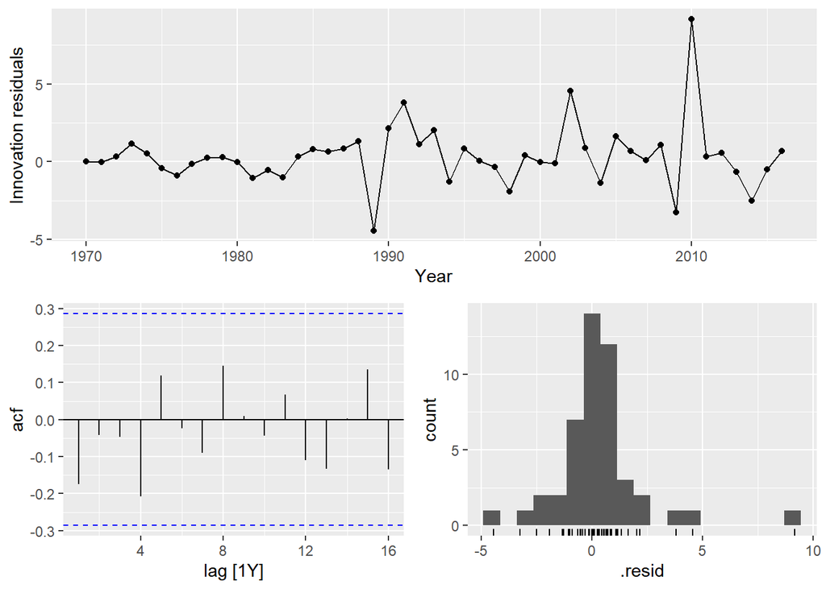

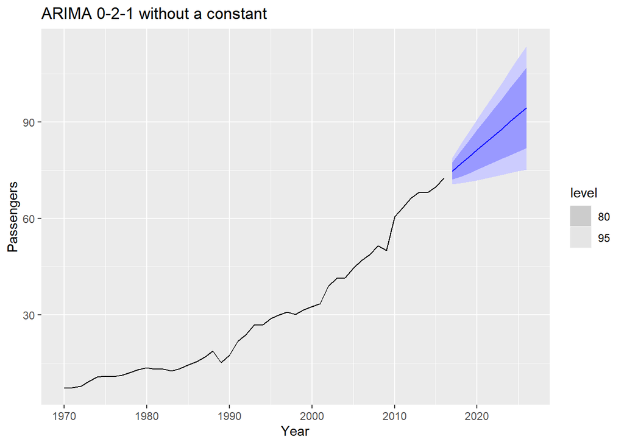

```
## Series: Passengers
## Model: ARIMA(0,2,1)
##
## Coefficients:
##           ma1
##       -0.8963
## s.e.   0.0594
##
## sigma^2 estimated as 4.308:  log likelihood=-97.02
## AIC=198.04   AICc=198.32   BIC=201.65
```

### 9.8

*9.8 For the United States GDP series (from global_economy):*

*a. if necessary, find a suitable Box-Cox transformation for the data.*

There is no need for boxcox from a variance point of view, but the transformation might make the model more linear. Lambda is .282.

```
## [1] 0.2819443
```

*b. fit a suitable ARIMA model to the transformed data using ARIMA();*

```
## Series: GDP
## Model: ARIMA(0,2,2)
##
## Coefficients:
##           ma1      ma2
##       -0.4206  -0.3048
## s.e.   0.1197   0.1078
##
## sigma^2 estimated as 2.615e+22:  log likelihood=-1524.08
## AIC=3054.15   AICc=3054.61   BIC=3060.23
```

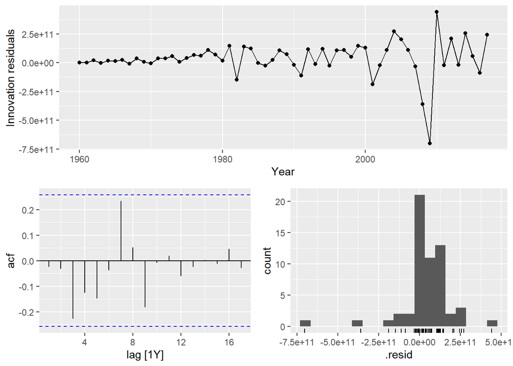

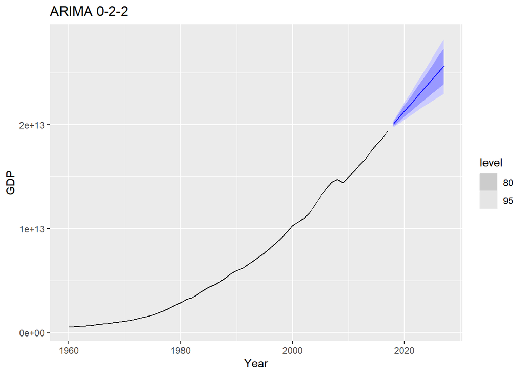

*c. try some other plausible models by experimenting with the orders chosen*

1. 1,2,2. This model has virtually the same AIC - the AR(1) does nothing to improve the model.

```
## Series: GDP
## Model: ARIMA(1,2,2)
##
## Coefficients:
##          ar1      ma1      ma2
##       0.2053  -0.5912  -0.1928
## s.e.  0.3008   0.2886   0.2102
##
## sigma^2 estimated as 2.646e+22:  log likelihood=-1523.86
## AIC=3055.72   AICc=3056.51   BIC=3063.82
```

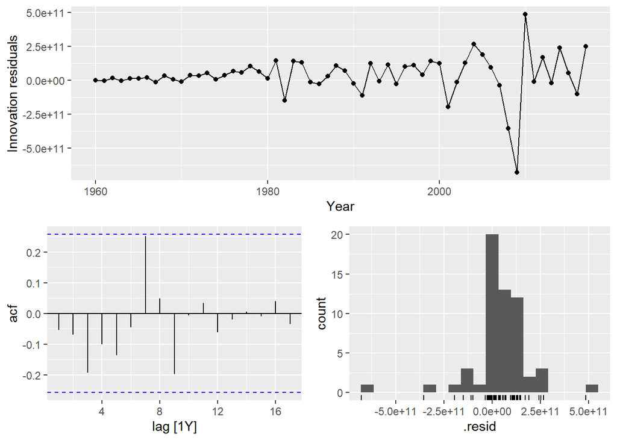

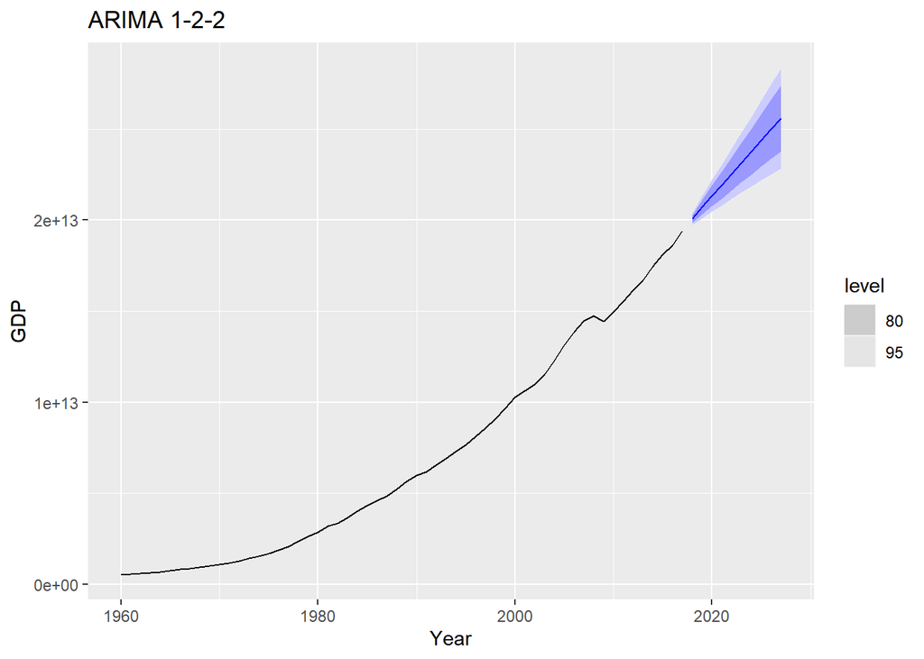

2. 0,1,2. This model has a higher AIC and the residuals are not centered at zero. The forecast does not account for the trend.

```
## Series: GDP
## Model: ARIMA(0,1,2)
##
## Coefficients:
##          ma1     ma2
##       0.9553  0.6807
## s.e.  0.0894  0.1190
##
## sigma^2 estimated as 5.067e+22:  log likelihood=-1570.65
## AIC=3147.29   AICc=3147.74   BIC=3153.42
```

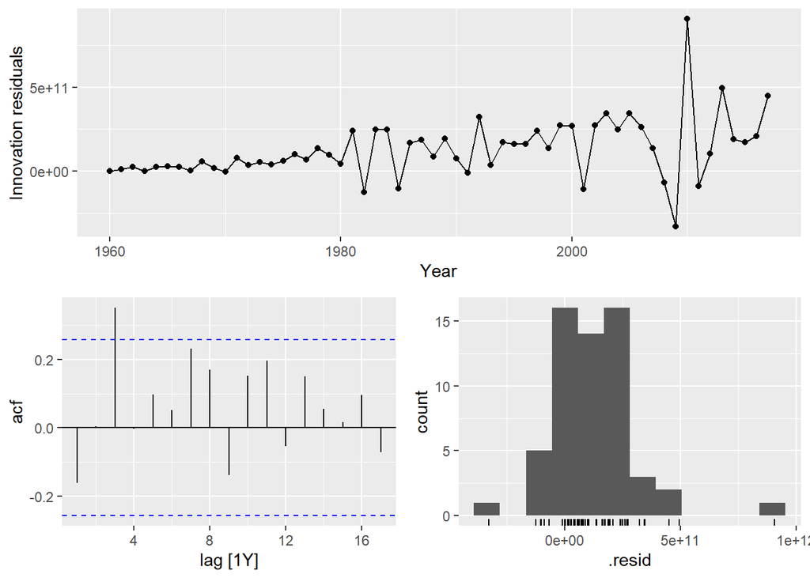

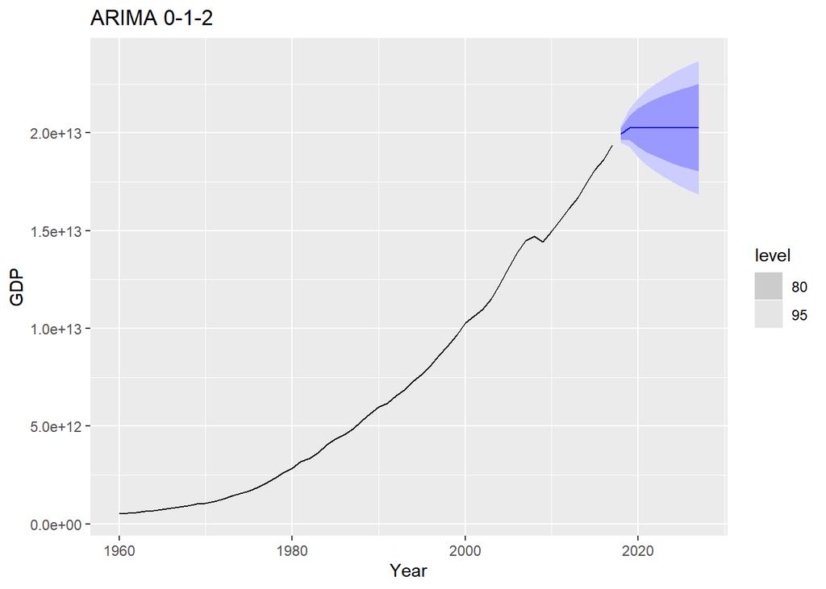

*d+e. choose what you think is the best model and check the residual diagnostics; produce forecasts of your fitted model. Do the forecasts look reasonable?*

This was done above.

*f. compare the results with what you would obtain using ETS() (with no transformation).*

The residuals are white noise. The ETS model looks similar to the ARIMA model but with a larger confidence interval.

```
## Series: GDP
## Model: ETS(M,M,N)
##   Smoothing parameters:
##     alpha = 0.9998963
##     beta  = 0.2671044
##
##   Initial states:
##         l[0]     b[0]
##  4.59552e+11 1.101027
##
##   sigma^2:  6e-04
##
##      AIC     AICc      BIC
## 3185.757 3186.911 3196.060
```

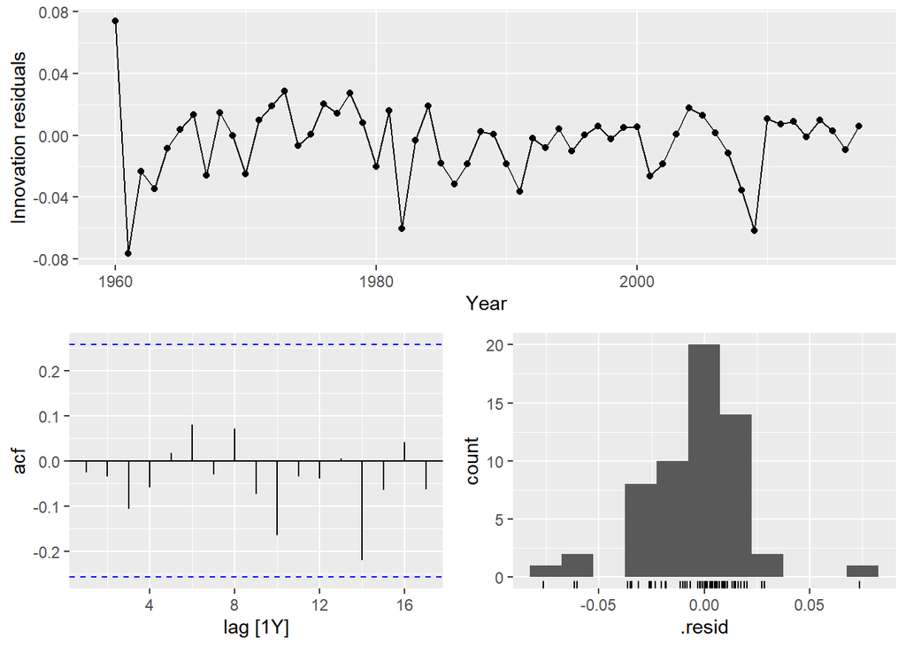

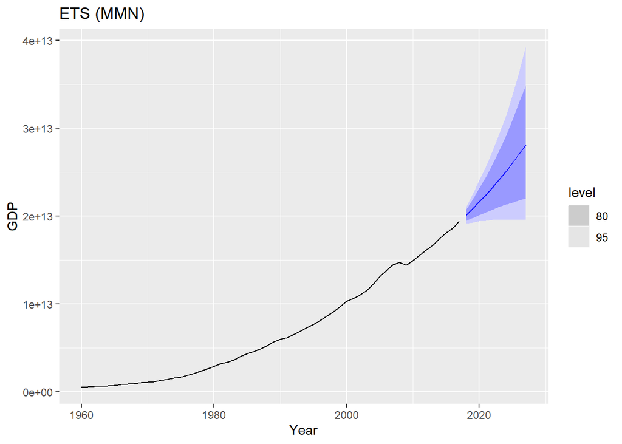